# HSG Transparency Report

Winter 2026 Budget Allocation

# HSG Transparency Report

This report summarizes the Winter 2026 HSG budget allocation cycle, including total funding requested, final allocations, award rates, spending categories, and event-level request details where available.

# Letter from the Committee

The purpose of this report is to make the budget allocation process easier to understand for students and organizations. Student organizations submitted requests for events, programming, supplies, speaker costs, refreshments, equipment, and other eligible expenses. The allocation process required balancing organizational needs against a limited funding pool while maintaining consistency, fairness, and transparency across applicants.

# Winter 2026 at a Glance

$40,004

Total Requested

$18,435

Total Allocated

46.1%

Overall Funding Rate

80

Events Reviewed

Across all organizations included in the final allocation table, total requested funding exceeded the final amount allocated. The overall funding rate provides a single measure of how much of requested funding was awarded across the cycle.

# How to Read This Report

# Allocation Methodology

### Equity

Requests were reviewed with attention to consistency across organizations and proportionality between request size, event scope, and student impact.

### Impact

Expected attendance, event reach, and the likely benefit to the Harris community were central considerations in comparing requests.

### Stewardship

The final allocations reflect the need to distribute limited student funds responsibly while supporting a broad range of programming.

# Overall Funding Outcomes

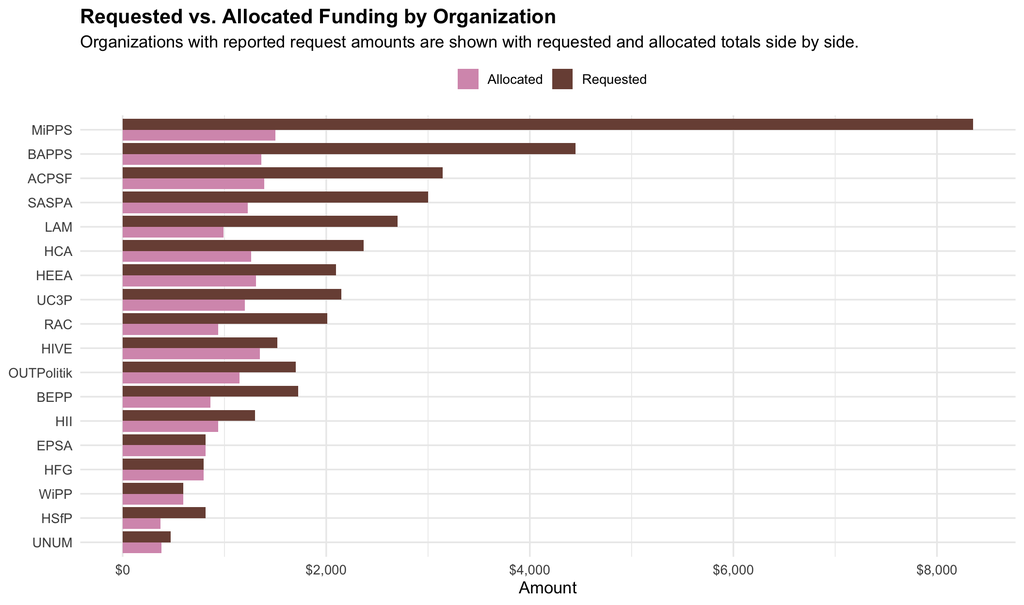

This chart shows the gap between submitted requests and final allocations. Organizations with larger requested budgets generally create more pressure on the funding pool, especially when total demand exceeds available resources.

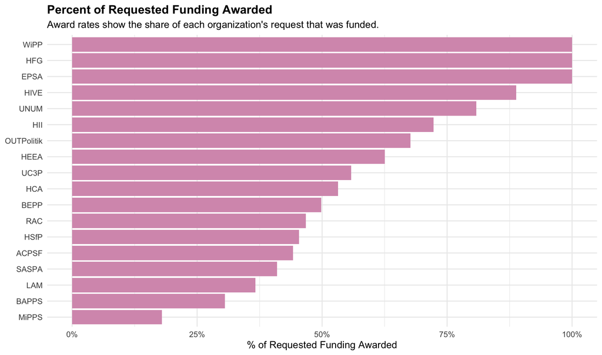

The award-rate chart helps distinguish between organizations that received high dollar amounts and organizations that received a high share of their requested amount. These are related but not identical measures.

# Organizations Receiving the Largest Allocations

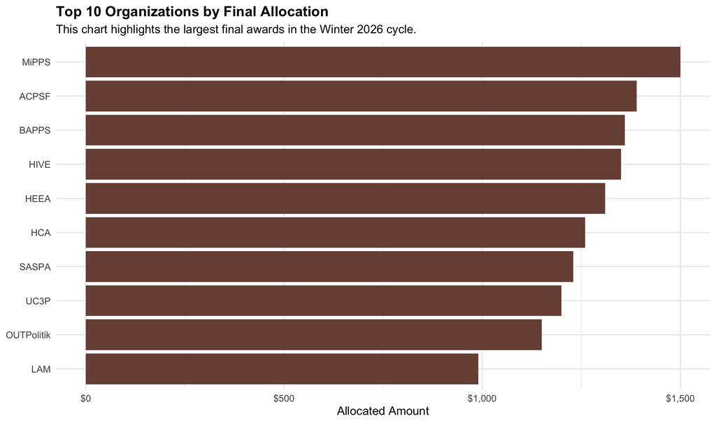

The organizations shown here received the largest final allocations. Larger final awards may reflect larger event portfolios, higher expected attendance, or more resource-intensive programming needs.

# Request Size and Funding Pressure

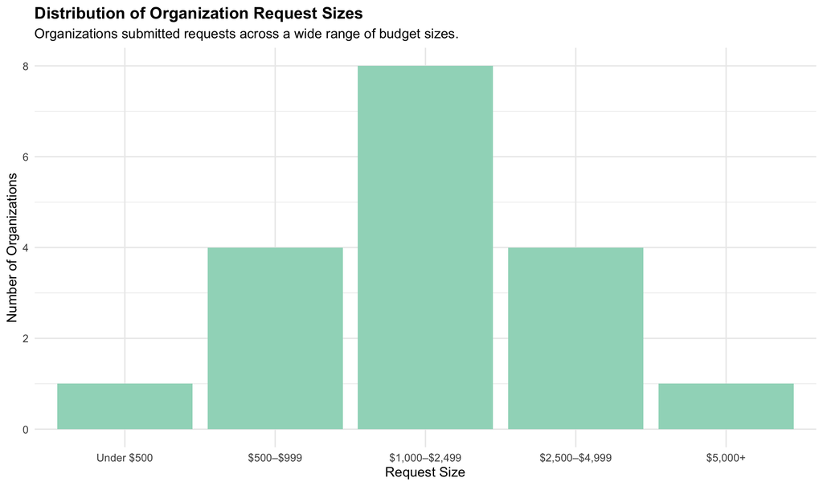

Request-size categories help contextualize the allocation challenge. A small number of large requests can account for a substantial share of total requested funding.

# What Organizations Requested Funding For

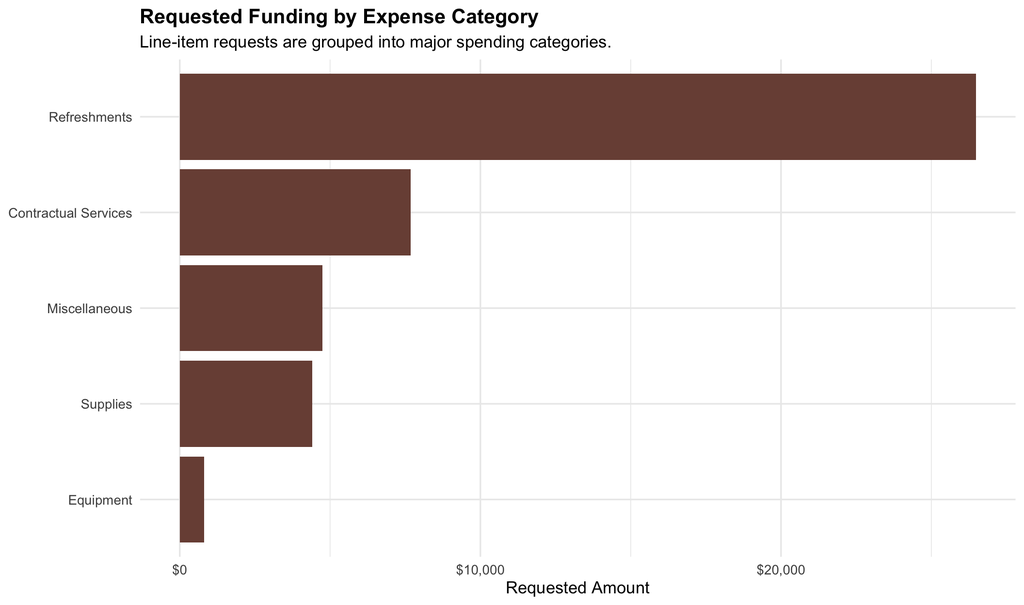

Category-level spending shows what student organizations were trying to fund. These categories may include refreshments, equipment, contractual services, supplies, and miscellaneous expenses, depending on how organizations completed their request forms.

Requested Spending by Category

| Category | Amount | Share |
| --- | --- | --- |
| Refreshments | $26,481 | 60.0% |
| Contractual Services | $7,674 | 17.4% |
| Miscellaneous | $4,748 | 10.8% |
| Supplies | $4,409 | 10.0% |
| Equipment | $810 | 1.8% |

# Event-Level Patterns

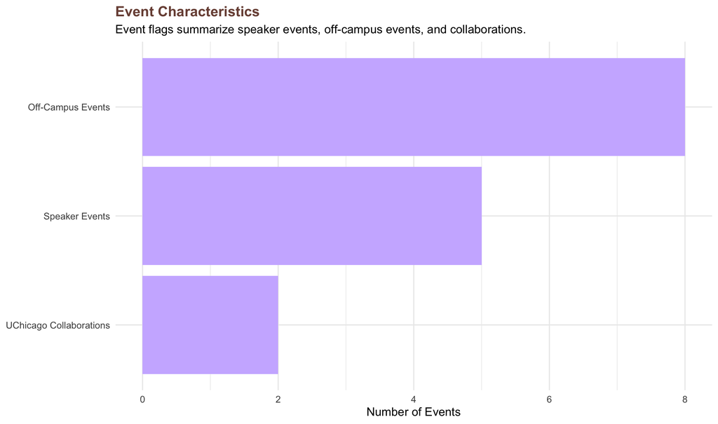

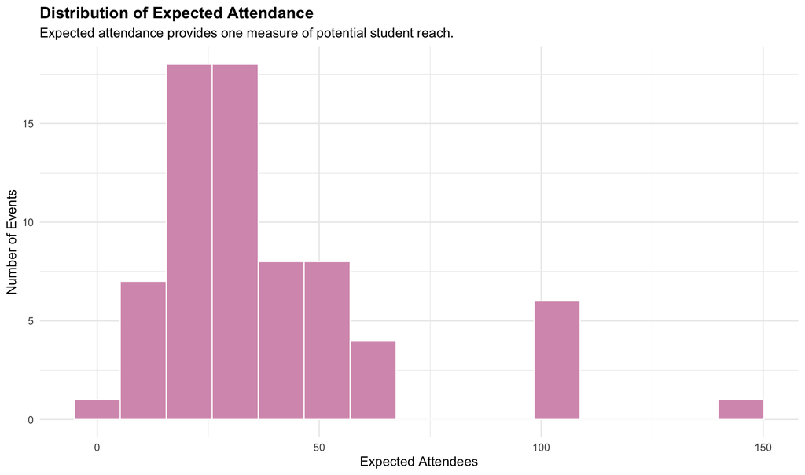

Event-level information is useful for understanding how organizations translated funding requests into specific programs. Attendance projections are self-reported and should be interpreted as planning estimates rather than final attendance counts.

# Conclusion and Future Improvements

This report aimed to improve transparency and consistency in the Winter 2026 HSG budget allocation process by summarizing funding outcomes, comparing requests with final allocations, and documenting key spending patterns across organizations. Overall, the process reflects an effort to balance fairness, student impact, and responsible stewardship of limited funds.

Looking ahead, future allocation cycles could be strengthened through more consistent event reporting, clearer budget request templates, and stronger assessment of event reach and attendance. Additional collaboration across student organizations may also help expand impact while making more efficient use of available resources.

Sincerely,

Manuela Restrepo, Finance Committee Chair

Shuyan Xin, Second-Year Finance Committee Member

Hanxi Meng, Second-Year Finance Committee Member

Dasia Bandy, Second-Year Finance Committee Member

Organization Abbreviations Used in This Report

| Abbreviation | Organization Name |
| --- | --- |
| PMPSA | Public Management & Policy Student Association |
| BAPPS | Black Action in Public Policy Studies |
| HCA | Harris Community Action |
| EPSA | Education Policy Student Association |
| MiPPS | Minorities in Public Policy Studies |
| HFG | Harris Finance Group |
| BEPP | Behavioral Science in Public Policy |
| HII | Harris Impact Investing |
| OUTPolitik | OUTPolitik |
| HEEA | Harris Energy & Environmental Association |
| TAP | The Asia-Pacific Policy Group |
| Agora | Agora |
| ACPSF | Anti-Caste Policy Students Forum |
| HIVE | Harris Innovation & Venture Ecosystem |
| MPP | Master of Public Policy Student Org |
| HNI | Harris Nonprofit Initiative |
| WiPP | Women in Public Policy |
| SASPA | South Asian Students’ Policy Association |
| LAM | Latin American MPP Association |
| MASH | Midwest Association of Students at Harris |
| RPD | Rural Policy & Development at Harris |

[output not shown]